# Simulation in R

As an introduction to using simulation imagine you knew that man have a mean height of 175.4 cm with s=7.3 and woman 165 cm and s=6.8. If you would pick randomly 10 people, what will be their average height?

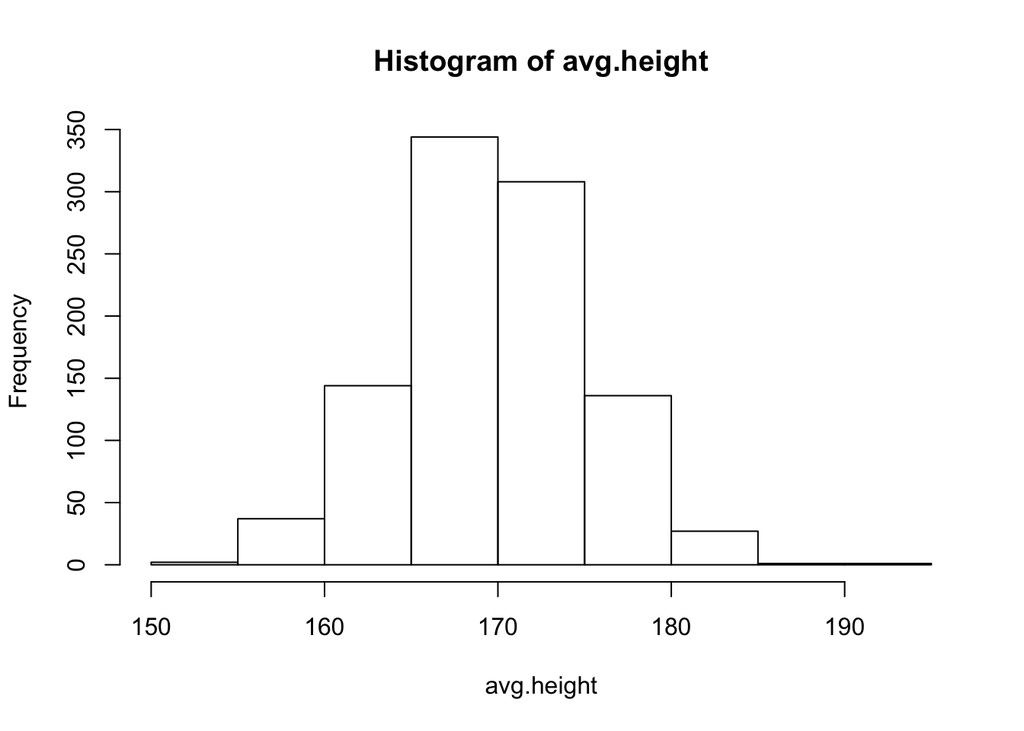

```r
avg.height <- rep(NA, 1000)
for (i in c(1:1000)) {
  sex <- rbinom(10, 1, 0.52)
  heights <- ifelse(sex==0, rnorm(1, 175.4, 7.3), rnorm(1, 165, 6.8))
  avg.height[i] <- mean(heights)
}
hist(avg.height)
```

## Why use simulation?

For illustration we use the following linear regression model:

```r
getwd()
```

```
## [1] "/Users/henrikeckermann/Documents/workspace/website/mysite/main/templates/stats"
```

```r
setwd('linear_regression/arm_linear_r/earnings')
library(foreign)
df <- read.dta('heights.dta')
df <- na.omit(df)
df$learn <- log(df$earn+1)
model <- lm(learn ~ sex*height, data=df)
summary(model)
```

```
##
## Call:
## lm(formula = learn ~ sex * height, data = df)
##
## Residuals:
##     Min      1Q  Median      3Q     Max
## -9.8617 -0.0538  0.9083  2.0379  4.6064
##
## Coefficients:
##             Estimate Std. Error t value Pr(>|t|)
## (Intercept) 14.56975    7.39047   1.971   0.0489 *
## sex         -7.85785    4.44019  -1.770   0.0770 .
## height      -0.04911    0.10681  -0.460   0.6457
## sex:height   0.09225    0.06562   1.406   0.1600
## ---
## Signif. codes:  0 '***' 0.001 '**' 0.01 '*' 0.05 '.' 0.1 ' ' 1
##
## Residual standard error: 3.266 on 1375 degrees of freedom
## Multiple R-squared:  0.09848,    Adjusted R-squared:  0.09651
## F-statistic: 50.06 on 3 and 1375 DF,  p-value: < 2.2e-16
```

$$log(earnings) ~ -7.85sex -0.05height + 0.09sex \times height$$

When using regression models in R with sample sizes large enough to apply the central limit theorem, for most situations obtaining point estimates with the predict function incl. the prediction intervals is sufficient. For other situations however, simulation is the easiest way to obtain an uncertainty interval. Imagine for example you want to estimate what is the difference in earnings between a man that is 187cm tall and a woman who is 187cm tall in a model like this: $earnings ~??height + sex$. Simulation is the easiest way to obtain that. Generally, simulation allows to summarize any function of estimated and predicted values.

## Represent uncertainty in regression coefficients

The uncertainty of the regression model does not only concern the individual predictors but also the combinations of the coefficients. Using the function `sim()` in R we can simulate the full model. This results in a matrix where each row is a set of the coefficients and an additional vector of the residual standard deviation sigma.

```r
library(arm)
sim.1 <- sim(model)
height.coef <- sim.1@coef[,3]
mean(height.coef)
```

```
## [1] -0.05555375
```

```r
quantile(height.coef, c(0.025, .975))
```

```
##       2.5%      97.5%
## -0.2533436  0.1358945
```

```r
summary(model)
```

```
##
## Call:
## lm(formula = learn ~ sex * height, data = df)
##
## Residuals:
##     Min      1Q  Median      3Q     Max
## -9.8617 -0.0538  0.9083  2.0379  4.6064
##
## Coefficients:
##             Estimate Std. Error t value Pr(>|t|)
## (Intercept) 14.56975    7.39047   1.971   0.0489 *
## sex         -7.85785    4.44019  -1.770   0.0770 .
## height      -0.04911    0.10681  -0.460   0.6457
## sex:height   0.09225    0.06562   1.406   0.1600
## ---
## Signif. codes:  0 '***' 0.001 '**' 0.01 '*' 0.05 '.' 0.1 ' ' 1
##
## Residual standard error: 3.266 on 1375 degrees of freedom
## Multiple R-squared:  0.09848,    Adjusted R-squared:  0.09651
## F-statistic: 50.06 on 3 and 1375 DF,  p-value: < 2.2e-16
```

### Exercise 7.6

#### 1

Discrete probability simulation: suppose that a basketball player has a 60% chance of making a shot, and he keeps taking shots until he misses two in a row. Also assume his shots are independent (so that each shot has 60% proba- bility of success, no matter what happened before).

##### A

Write an R function to simulate this process.

```r
bbsim <- function() {
  pshot <- 1
  shot <- 1
  counter <- 0
  successes <- 0
  while (shot+pshot>0) {
    pshot <- shot
    shot <- rbinom(1,1,0.6)
    counter <- counter + 1
    if (shot==1) {
      successes <- successes +1
    }
  }
  return(c(counter, successes))
}
```

#### B

Put the R function in a loop to simulate the process 1000 times. Use the simulation to estimate the mean, standard deviation, and distribution of the total number of shots that the player will take.

```r
shots <- data.frame(matrix(rep(NA, 2000), ncol=2))
colnames(shots) <- c('shots', 'successes')
for (i in c(1:1000)) {
  trial <- bbsim()
  shots[i, 'shots'] <- trial[1]
  shots[i, 'successes'] <- trial[2]
}
mean(shots[, 'shots'])
```

```
## [1] 8.687
```

```r
sd(shots$shots)
```

```
## [1] 6.804655
```

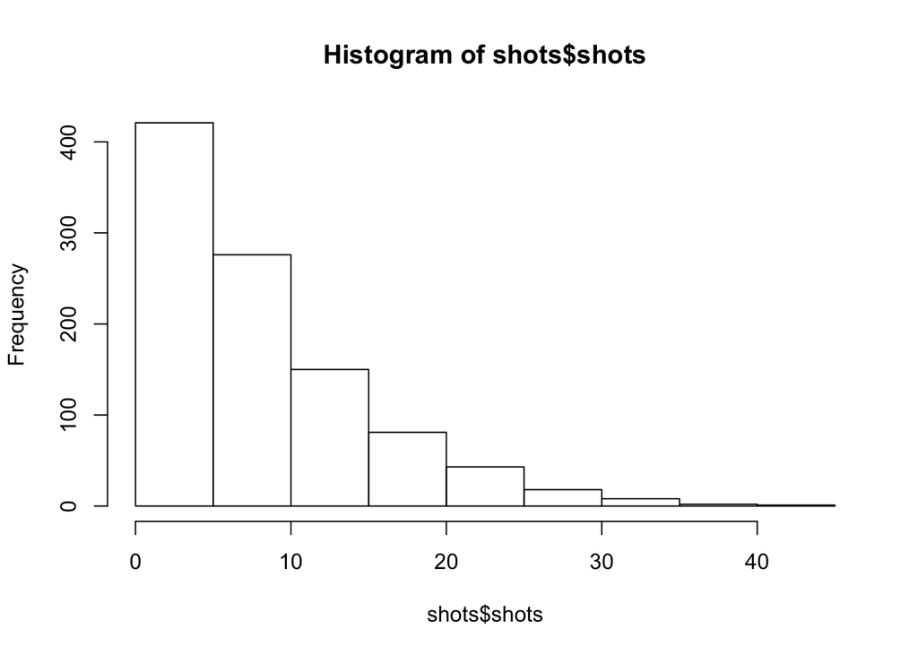

```r
hist(shots$shots)
```

#### Part C

Using your simulations, make a scatterplot of the number of shots the player will take and the proportion of shots that are successes.

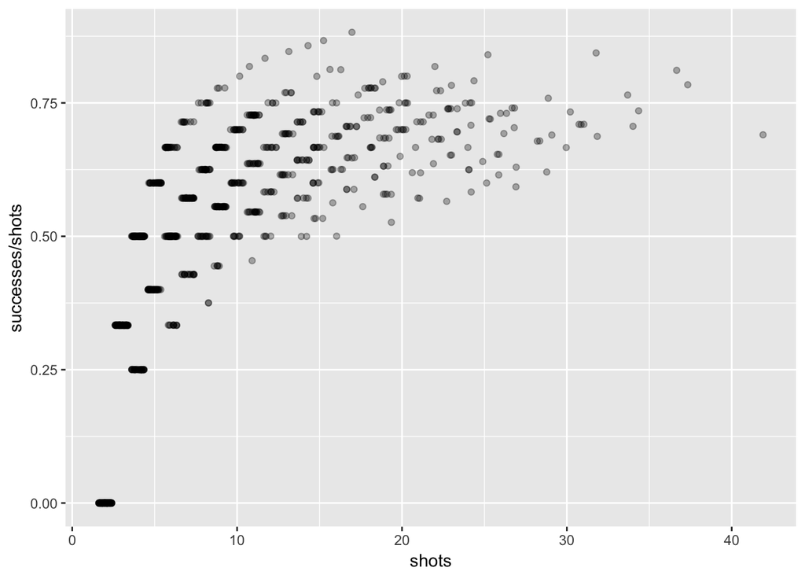

```r
library(ggplot2)
ggplot(shots, aes(shots, successes/shots)) +
  geom_jitter(alpha=0.3)
```

#### 2

```r
rnorm(1, 5.13, 0.17)
```

```
## [1] 5.123289
```

```r
rnorm(1, 4.96, 0.20)
```

```
## [1] 4.959505
```

```r
rbinom(1, 1, 0.5)
```

```
## [1] 0
```

```r
ifelse(rbinom(1, 1, 0.5)==1, rnorm(1, 5.13, 0.17), rnorm(1, 4.96, 0.20))
```

```
## [1] 5.130224
```

```python
2+4
```